# 공간통계를 위한 데이터 사이언스

`.shp` 지도 일부 추출

xwMOOC

2019-03-12

# 1 `shapefile?`

Shapefile은 확장자로 `.shp`을 갖고, 벡터방식으로 공간정보를 저장한다. `.shp` 파일은 점(Point), 선(Line), 면(Polygon) 중 하나의 속성을 갖는다. `.shp` 파일에서 면(polygon)을 잘라내거나 [^1] `.shp` 파일에서 면(polygon)을 합칠 수도 있다. [^2]

# 2 성남시

시군구 Shapefile에서 성남시를 추출하고, 성남시를 구성하는 중원구, 수정구, 분당구로 나눠진 것을 확인해보자. 이 단순한 작업을 위해서 [대한민국 최신 행정구역(SHP) 다운로드](http://www.gisdeveloper.co.kr/?p=2332) 웹사이트에서 **시군구** `2019년 2월 업데이트 다운로드` 기준 파일을 사용하자.

## 2.1 시군구 Shapefile

`sf` 팩키지로 시군구 `shapefile`을 불러온다. 그리고 나서 인코딩을 `CP949`에서 `UTF-8`으로 변경을 한다. 그리고 나서, `st_read()` 함수로 `shapefile`을 불러오게 되면 `sf data.frame` 객체라서 `dplry` 동사를 자유로이 활용할 수 있다. 따라서 `SIG_KOR_NM` 칼럼만 추출하여 `plot()` 함수로 시각화한다.

```r
library(tidyverse)
library(sf)

sigungu_shp <- st_read("data/shapefile/SIG_201902/TL_SCCO_SIG.shp")
```

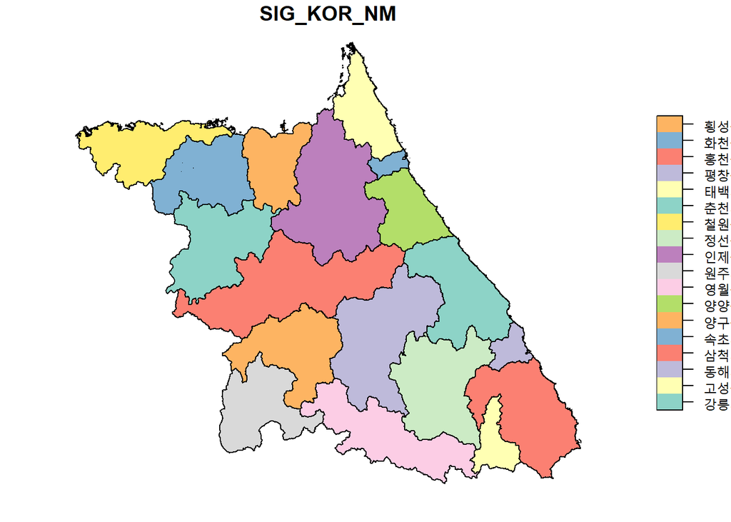

```r
## 인코딩 변경
sigungu_shp$SIG_KOR_NM <- iconv(sigungu_shp$SIG_KOR_NM, from = "CP949", to = "UTF-8", sub = NA, mark = TRUE, toRaw = FALSE)

## 시각화
sigungu_shp %>%
  filter(str_detect(SIG_CD, "^42")) %>%
  select(SIG_KOR_NM) %>%
  plot()
```

다음으로 성남시만 추출하여 동일한 방식으로 시각화한다. 이번에는 성남시관련 전체 칼럼을 지정하여 식가화 시킨다.

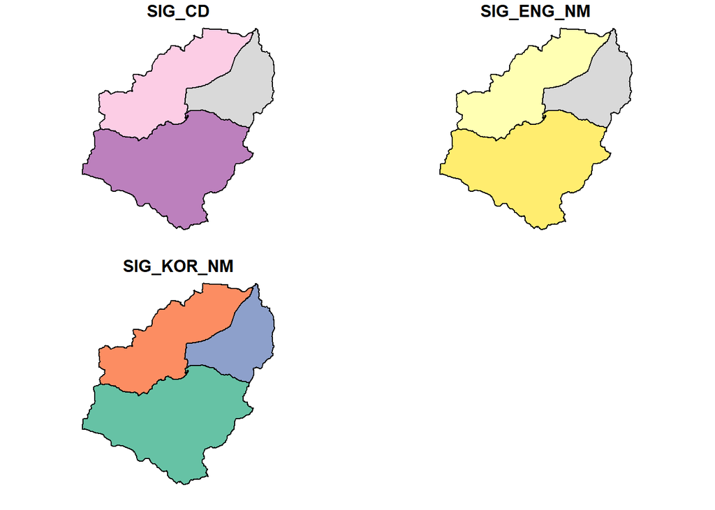

```r
sungnam_shp <- sigungu_shp %>%
  filter(str_detect(SIG_KOR_NM, "성남"))

sungnam_shp %>%
  plot()
```

나중에 성남시만 별도 작업을 하는 경우를 대바하여 `sungnam` 디렉토리를 생성하고 `sungnam.shp` 파일명으로 저장시킨다.

```r
dir.create('data/shapefile/SIG_201902/sungnam')
st_write(sungnam_shp, "data/shapefile/SIG_201902/sungnam/sungnam.shp", delete_dsn=TRUE)
```

```
Deleting source `data/shapefile/SIG_201902/sungnam/sungnam.shp' using driver `ESRI Shapefile'
Writing layer `sungnam' to data source `data/shapefile/SIG_201902/sungnam/sungnam.shp' using driver `ESRI Shapefile'
features:       3
fields:         3
geometry type:  Multi Polygon
```

## 2.2 읍면동 Shapefile

시군구 `shapefile` 작업을 했을 때와 동일한 방식으로 작업을 수행하는데 이번에는 읍면동 `shapefile`을 사용한다. 읍면동 `shapefile`에 시군구 정보가 빠져있다 보니 [행정안전부 지방행정실 홈페이지](https://www.mois.go.kr/frt/bbs/type001/commonSelectBoardList.do?bbsId=BBSMSTR_000000000052)에서 “행정동코드(전체) 및 법정동·행정동코드”을 참조하여 수정구, 중원구, 분당구를 구분하는 필드를 `SIGUNGU`로 추가하여 시각화를 한다.

```r
emd_shp <- st_read("data/shapefile/EMD_201902/TL_SCCO_EMD.shp")
```

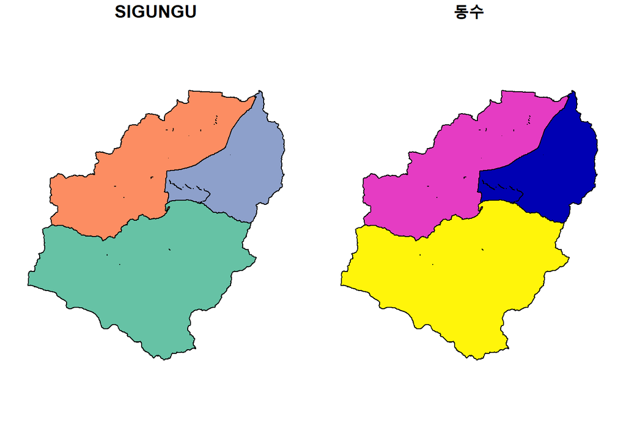

```r
## 인코딩 변경
emd_shp$EMD_KOR_NM <- iconv(emd_shp$EMD_KOR_NM, from = "CP949", to = "UTF-8", sub = NA, mark = TRUE, toRaw = FALSE)

## 성남시 행정동 코드: 4113000000
sungnam_emd_shp <- emd_shp %>%
  mutate(SIGUNGU = case_when(str_detect(EMD_CD, "^41131") ~ "수정구",
                             str_detect(EMD_CD, "^41133") ~ "중원구",
                             str_detect(EMD_CD, "^41135") ~ "분당구")) %>%
  filter(!is.na(SIGUNGU))

## 시각화
sungnam_emd_shp %>%
  group_by(SIGUNGU) %>%
  summarise(`동수` = n()) %>%
  plot()
```

이번에는 분당구만 대상으로 동을 지도평면위에 시각화한다.

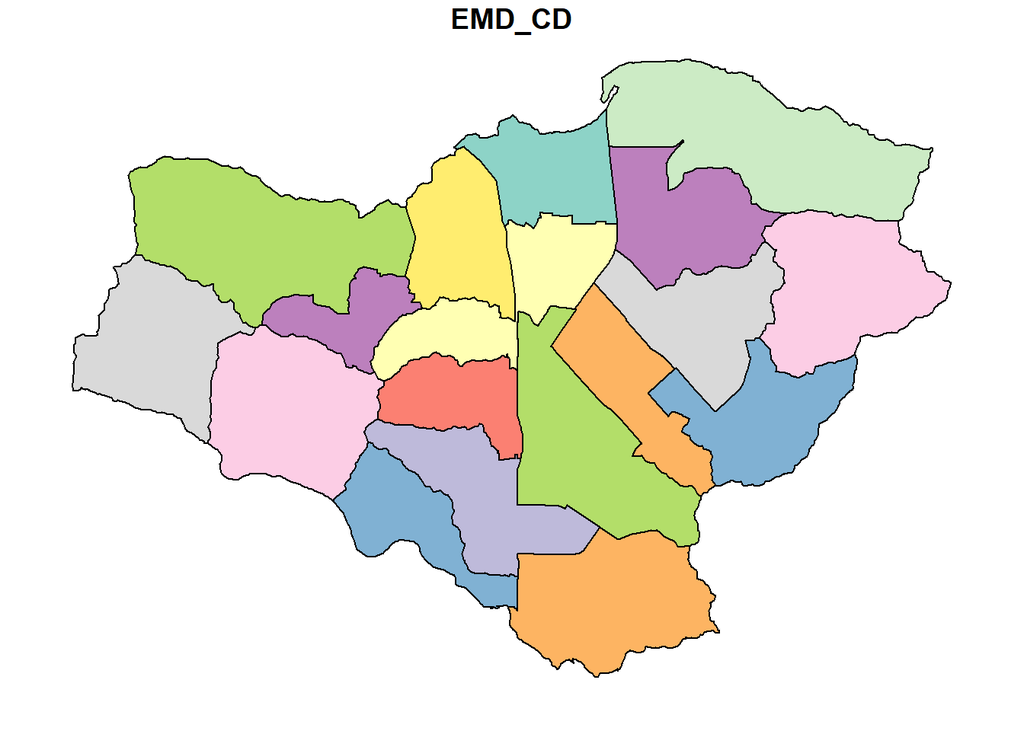

```r
## 시각화
sungnam_emd_shp %>%
  filter(SIGUNGU == "분당구") %>%
  select(EMD_CD) %>%
  plot()
```

마지막으로 성남시 시군구 읍면동까지 잘 정리된 `shapefile`을 저장하여 다음 교차분석을 준비한다.

```r
## shapefile 저장
dir.create('data/shapefile/SIG_201902/sungnam')
st_write(sungnam_emd_shp, "data/shapefile/SIG_201902/sungnam/sungnam_emd.shp", delete_dsn=TRUE)
```

```
Deleting source `data/shapefile/SIG_201902/sungnam/sungnam_emd.shp' using driver `ESRI Shapefile'
Writing layer `sungnam_emd' to data source `data/shapefile/SIG_201902/sungnam/sungnam_emd.shp' using driver `ESRI Shapefile'
features:       44
fields:         4
geometry type:  Multi Polygon
```

## 2.3 시군구 읍면동 좌표계

[대한민국 최신 행정구역(SHP) 다운로드](http://www.gisdeveloper.co.kr/?p=2332)로 작업한 지도파일은 `proj4string: "+proj=tmerc +lat_0=38 +lon_0=127.5 +k=0.9996 +x_0=1000000 +y_0=2000000 +ellps=GRS80 +units=m +no_defs"`을 구글링해서 얻은 정보를 통해 `EPSG:5179`로 확인되고 네이버지도에서 사용중인 좌표계라고 한다. [^3]

```r
st_crs(sigungu_shp)
```

```
Coordinate Reference System:
  No EPSG code
  proj4string: "+proj=tmerc +lat_0=38 +lon_0=127.5 +k=0.9996 +x_0=1000000 +y_0=2000000 +ellps=GRS80 +units=m +no_defs"
```

```r
st_crs(emd_shp)
```

```
Coordinate Reference System:
  No EPSG code
  proj4string: "+proj=tmerc +lat_0=38 +lon_0=127.5 +k=0.9996 +x_0=1000000 +y_0=2000000 +ellps=GRS80 +units=m +no_defs"
```

# 3 `ggplot` 시각화

sf 데이터프레임을 shapefile 변환시키는데 `sf:::as_Spatial()` 함수를 사용한다. 혹은 `as(sungnam_df_shp, 'Spatial')`을 사용해도 좋다. 다음으로 `SpatialPolygonsDataFrame`을 데이터프레임으로 변환시킨다. 이를 `geom_path()`로 시각화한다.

```r
sungnam_df_shp <-  emd_shp %>%
    mutate(SIGUNGU = case_when(str_detect(EMD_CD, "^41131") ~ "수정구",
                               str_detect(EMD_CD, "^41133") ~ "중원구",
                               str_detect(EMD_CD, "^41135") ~ "분당구")) %>%
    filter(!is.na(SIGUNGU))

## sf 데이터프레임 --> shapefile 변환
# sungnam_emd_shp <-  sf:::as_Spatial(sungnam_df_shp$geometry)
sungnam_emd_shp <-  as(sungnam_df_shp, 'Spatial')

class(sungnam_emd_shp)
```

```
[1] "SpatialPolygonsDataFrame"
attr(,"package")
[1] "sp"
```

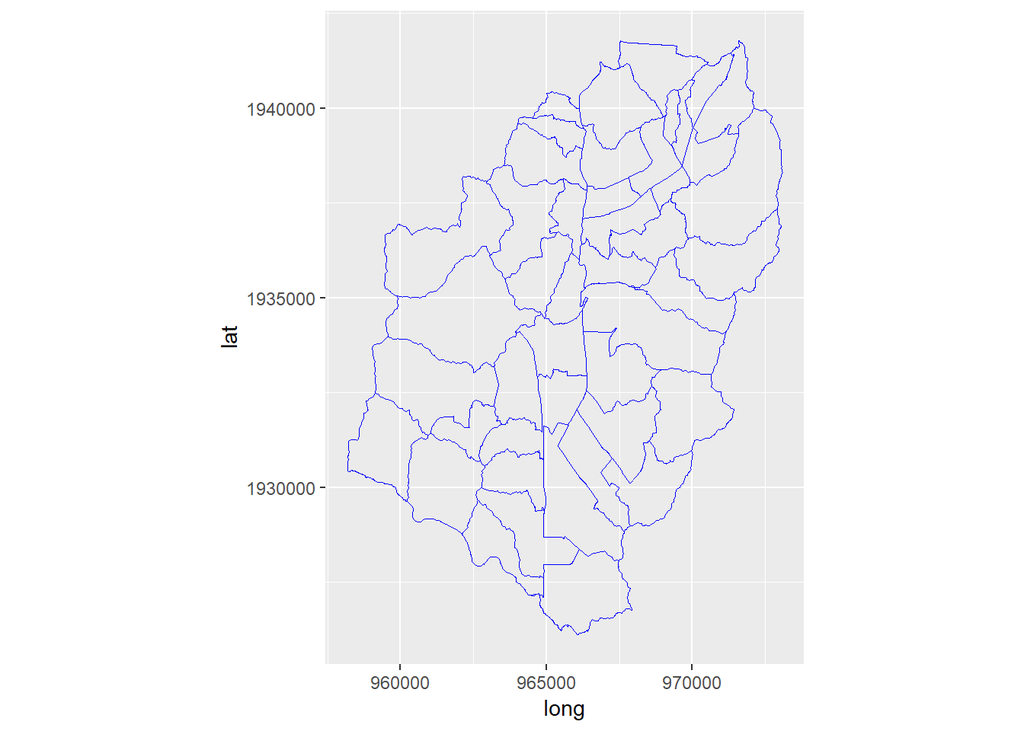

```r
## shapefile --> 데이터프레임 변환
sungnam_emd_df <- fortify(sungnam_emd_shp)

## ggplot 시각화
sungnam_emd_df %>%
  ggplot(aes(x = long, y = lat, group = group)) +
    geom_path(color = 'blue', size = .2) +
    coord_fixed(1.3)
```

다른 방식으로 `geom_polygon()` 함수를 사용해서 `ggplot` 시각화도 가능하다.

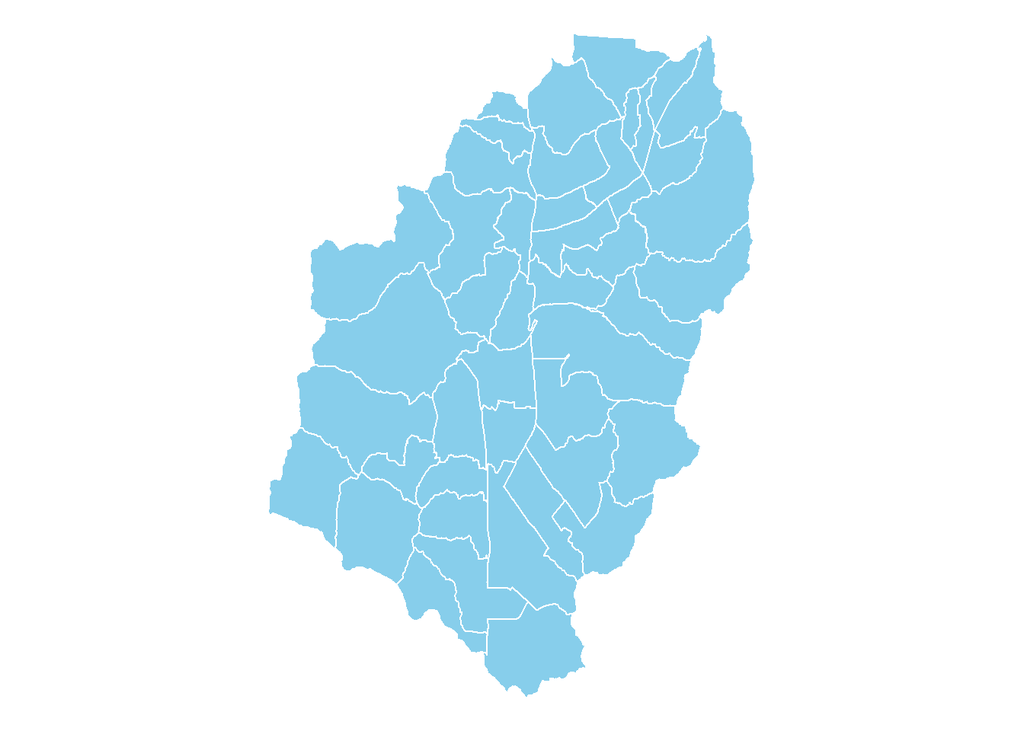

```r
sungnam_emd_df %>%
  ggplot(aes(x = long, y = lat, group = group)) +
    geom_polygon(color = "white", fill="skyblue") +
    coord_fixed(1.3) +
    guides(fill=FALSE) +
    theme_void()
```

[^1]: [Clipping polygons in R](https://philmikejones.wordpress.com/2015/09/01/clipping-polygons-in-r/)
[^2]: [Dissolve polygons in R](https://philmikejones.wordpress.com/2015/09/01/clipping-polygons-in-r/)
[^3]: [VISUALIZING STORY (STORY ABOUT TRUTH AND LIFE), “한국 주요 좌표계 EPSG코드 및 PROJ4 인자 정리”](https://visualizingstory.wordpress.com/2013/04/24/%ED%95%9C%EA%B5%AD-%EC%A3%BC%EC%9A%94-%EC%A2%8C%ED%91%9C%EA%B3%84-epsg%EC%BD%94%EB%93%9C-%EB%B0%8F-proj4-%EC%9D%B8%EC%9E%90-%EC%A0%95%EB%A6%AC/)